# ogp03

```python
from IPython.core.interactiveshell import InteractiveShell

InteractiveShell.ast_node_interactivity = "all"
```

## Otimização de Grande Porte - CI - UFPB

- Prof. Miguel Aroztegui, DCC - CI - UFPB
- Periodo Suplementar 2020.2, 03/03/2021 - 03/07/2021.
- Encontro 03/34, 11/03/2021, 14:00-16:00 (gravado)
- [Moodle Classes](http://www.classes.sead.ufpb.br/course/view.php?id=461)
- [Frequência](https://forms.gle/Hz4y8zkUmDYGQxja8)

# Roteiro

- Redes Neurais Artificiais (RNA) e otimização
- Relação entre RNA e OGP
- Ajuste de funções aos dados
  - *Dataset* : como carregar e graficar
  - Vetores e funções: como definir e graficar
  - Ajustando gráfico de funções aos dados

## Redes Neurais Artificiais (RNA) e otimização

- Uma rede neural artificial (RNA) é uma técnica de aprendizagem supervisionada.
- A aprendizagem é realizada durante um processo de otimização.
  - Na literatura se diz que a RNA está "treinando" ou "aprendendo" quando se executa um algoritmo de otimização.
  - Para "treinar" ou "ensinar" uma RNA basta resolver um problema de otimização.
  - Este problema quer determinar uma função que se ajusta a um conjunto de dados ( *dataset* ).
  - A solução do problema de otimização é uma função preditora que melhor se ajusta aos dados.
- A grosso modo, são equivalentes as seguintes expressões:
  - "Treinamento/Aprendizagem" com *dataset* ,
  - Ajuste de função ao *dataset* ,
  - Resolver um problema de otimização.

### Qual é a relação entre RNA e OGP?

- As RNA profundas ( *deep neural networks* ) precisam resolver problemas de OGP sem restrições para "aprender/treinar" com o *dataset*.
- É por isso que usaremos algoritmos de OGP para fazer o processo de "aprendizado" de RNA profundas.
- Quanto mais profunda é a RNA mais variáveis de otimização terá o problema associado ao "treinamento"

## Ajuste de funções aos dados

- Ajustar funções aos dados é fazer que o gráfico de uma função passe o mais próximo dos pontos do *dataset*.
- Primeiro vamos resolver este problema de forma visual, usando gráficos do Python.
- Em aulas futuras empregaremos algoritmos de otimização para resolver o "aprendizado" de forma automática.

### O que é um *dataset* ?

- Um *dataset* é um conjunto de dados geralmente organizado em uma tabela:

  ```
  0.1 0.7 ... 0.2 0
  0.6 0.2 ... 0.9 1
  0.8 0.1 ... 0.3 1
  ...
  0.4 0.8 ... 0.1 0
  ```

- Cada linha do *dataset* se chama observação, exemplo, amostra ou medida.
- Uma linha começa com uma lista de atributos ( *features* ) e finaliza com uma ou mais respostas ( *response* , *label* ou *target* ).
  - No exemplo acima, na primeir linha se tem:

    ```
      0.1 0.7 ... 0.2 0
    ```

    - Ela indica que os atributos são números reais entre 0 e 1
    - Também indica que a resposta é 0.
  - Na segunda linha:

    ```
      0.6 0.2 ... 0.9 1
    ```

    - Ela indica que a resposta é 1.

### O que é um *dataset* ?

- O número de atributos e respostas de um *dataset* é geralmente fixo.
  - Notação: emprega-se $n$ para especificar o número de atributos.
  - Notação: emprega-se $m$ ou $N$ para especificar o número de linhas (número de observações, exemplos, ..., medidas).
  - No exemplo não se pode saber quanto é $n$ ou $m$ por causa das reticências.
    - O *dataset* pode ser representado por uma matriz com duas partes $$ \begin{array}{c} dataset=[X\ \ Y]\in\mathbb{R}^{m\times(n+1)}\\ X\in\mathbb{R}^{m\times n}\\ Y\in\mathbb{R}^{m\times 1}\\ \end{array} $$
      - $X$ é denominada matriz de atributos
      - $Y$ é denominada matriz de respostas (no exemplo é um vetor de $m$ entradas)

### O que significa um *dataset* ?

- Uma linha do *datset* é a codificação de uma informação.
  - Por exemplo: uma foto tem 256 pixels e nela se tem um gato ou um cachorro.
  - Um *dataset* de gatos e cachorros poderia caber em um arquivo de $m=1000$ linhas:
    - cada linha tem $n=256$ atritutos e no final um $0$ (gato) ou um $1$ (cachorro).

### Exercício

- Procure na web um *dataset* no formato de tabela.
- Identificar $m$ e $n$.
- Explicar cada um dos atributos e resposta.
- Imprimir uma linha do *dataset* e explicar o que significa cada atributo e resposta.
- Dica: procure no site do [scikit-learn](https://scikit-learn.org/stable/datasets/toy_dataset.html).

### Como carregar o *dataset* no Python

- Vamos ver uma forma de ler um arquivo que contem um *dataset*.
- Vamos guardar os atributos em $X$ e as respostas em $Y$.

```python
from numpy import *
# atenção pessoal: para executar a seguinte linha
# o arquivo tem que estar na mesma pasta
# onde se encontra este programa!
arquivo = open('dataset00.txt', 'r')

# A seguinte linha carrega na variável,
# todas as linhas do arquivo e coloca
# muma uma lista.
linhas = arquivo.readlines()
print('Readline retornou o seguinte:')
print(linhas)

m=len(linhas) # número de linhas
n=len(linhas[0].strip().split()) # número de colunas
n=n-1 # número de atributos
print('\nDataset com m=',m,'exemplos e n=',n,'atributos.\n')
X=zeros((m,n))
Y=zeros((m,1))

# vamos separa os atributos e a resposta
# depois colocamos os atributos em X
# e a resposta em Y
i=0
for linha in linhas:
    linha=linha.strip().split() # retira '\n' e separa entradas
    X[i,:]=float(linha[0])
    Y[i,:]=float(linha[1])
    i+=1

print(hstack((X,Y)))
```

```
Readline retornou o seguinte:
['-10.00 -5.40\n', '-9.31 -4.97\n', '-8.62 -6.34\n', '-7.93 -4.54\n', '-7.24 -3.04\n', '-6.55 -3.83\n', '-5.86 -3.76\n', '-5.17 -2.16\n', '-4.48 -1.85\n', '-3.79 -5.06\n', '-3.10 -2.32\n', '-2.41 -2.94\n', '-1.72 -0.45\n', '-1.03 -2.10\n', '-0.34 -0.46\n', '0.34 -3.38\n', '1.03 -1.03\n', '1.72 0.53\…

Dataset com m= 30 exemplos e n= 1 atributos.

[[-10.    -5.4 ]
 [ -9.31  -4.97]
 [ -8.62  -6.34]
 [ -7.93  -4.54]
 [ -7.24  -3.04]
 [ -6.55  -3.83]
 [ -5.86  -3.76]
 [ -5.17  -2.16]
 [ -4.48  -1.85]
 [ -3.79  -5.06]
 [ -3.1   -2.32]
 [ -2.41  -2.94]
 [ -1.72  -0.45]
 [ -1.03  -2.1 ]
 [ -0.34  -0.46]
 [  0.34  -3.38]
 [  1.03  -1.03]
 [  1.72   0.53]
 [  2.41  -0.23]
 [  3.1    0.61]
 [  3.79   0.74]
 [  4.48   1.14]
 [  5.17   1.02]
 [  5.86   0.49]
 [  6.55   1.14]
 [  7.24   1.99]
 [  7.93   3.04]
 [  8.62   4.15]
 [  9.31   3.6 ]
 [ 10.     1.8 ]]
```

### Como graficar o *dataset* no Python

- Poderemos ver na tela do computador *datasets* com duas ou três colunas.
  - Se cada linha do *dataset* tiver um atributo $a_1$ e uma resposta $r_1$, então
    - graficamos o ponto $(a_1,r_1)$ no plano (usaremos matplotlib.pyplot.plot).
  - Se cada linha do *dataset* tiver dois atributos $a_1$ e $a_2$ e uma resposta $r_1$, então
    - graficamos o ponto $(a_1,a_2,r_1)$ no espaço (plot3D).
- Vamos começar por graficar um *dataset* com um atributo e uma resposta.

[output not shown]

[figure not shown]

```python
from numpy import *

def carregaDataSet(nomeArquivo):
    arquivo = open(nomeArquivo, 'r')
    linhas = arquivo.readlines()
    m=len(linhas) # número de linhas
    n=len(linhas[0].strip().split()) # número de colunas
    n=n-1 # número de atributos
    print('\nDataset com m=',m,'exemplos e n=',n,'atributos.\n')
    X=zeros((m,n))
    Y=zeros((m,1))
    i=0
    for linha in linhas:
        linha = linha.strip().split() # retira '\n' e separa entradas
        linha = [float(i) for i in linha]
        X[i,0:n] = linha[0:n]
        Y[i,0] = linha[n]
        i += 1
    return X, Y

X, Y = carregaDataSet('dataset00.txt') # faz a leitura do arquivo e define o dataset

m,n=X.shape
if n==1:
    import matplotlib.pyplot as plt
    plt.plot(X,Y,'r.')
else:
    import matplotlib.pyplot as plt
    from mpl_toolkits import mplot3d
    ax = plt.axes(projection='3d')
    ax.plot3D(X[:,0],X[:,1],Y[:,0],'r.')
```

### Exercício

- Escrever um código Python para
  - Carregar o '[dataset01](https://drive.google.com/file/d/1E68teCnvQa3j12HS66Wv5o33ZFy6vODZ/view?usp=sharing)'.
  - Graficar o *dataset*.

### Como graficar o *dataset* no Python

- Agora vamos graficar um *dataset* com dois atributo e uma resposta.
- Recomendo executar o seguinte script no Spyder ou no PyCharm, para poder rotar a figura.

```
Dataset com m= 50 exemplos e n= 2 atributos.
```

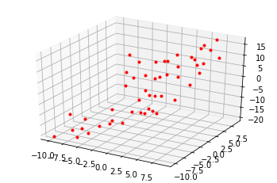

```python
X, Y = carregaDataSet('dataset03.txt') # faz a leitura do arquivo e define o dataset

m,n=X.shape
if n==1:
    import matplotlib.pyplot as plt
    plt.plot(X,Y,'r.')
else:
    import matplotlib.pyplot as plt
    from mpl_toolkits import mplot3d
    ax = plt.axes(projection='3d')
    ax.plot3D(X[:,0],X[:,1],Y[:,0],'r.')
```

### Exercício

- Escrever um código Python para
  - Carregar o '[dataset02](https://drive.google.com/file/d/18OgAeCuz7Og8bhg71VnXKBy3OTFj3Ol-/view?usp=sharing)'.
  - Graficar o *dataset*.

```python
# Como definir vetores no Python?
from numpy import zeros,ones,linspace

# Vetor com n entradas todas iguais a 0:
n=8
x=zeros(n)
print('x=',x)

# Vetor com n entradas todas iguais a 1:
n=4
y=ones(n)
print('y=',y)

# Vetor com n entradas igualmente espaçadas
# com primeira entrada a e última entrada b:
n=6
a=-1
b=3
z=linspace(a,b,n)
print('z=',z)
```

```
x= [0. 0. 0. 0. 0. 0. 0. 0.]
y= [1. 1. 1. 1.]
z= [-1.  -0.2  0.6  1.4  2.2  3. ]
```

```python
from numpy import array
# Como definir funções no Python?

# Função escalar de uma variável f(x)=x^3:
def f(x):
    return x**3

# Função escalar de duas variáveis
# g(x)=raizQuadrada(x[0]^2+x[1]^2):
def g(x):
    return sqrt(x[0]**2 + x[1]**2)

# Composição de funções: h(x)=f(g(x))
def h(x):
    return f(g(x))

# Funções com varios argumentos:
def fun(x,a,b):
    return a*exp(-a*(x-b)**2) # sino gaussiano

# Como empregar as funções acima definidas
y = f(10)
print(y)

x=array([1,2])
z = g(x)
print(z)

print(h(x))

print(fun(0,2,-1))
```

```
1000
2.23606797749979
11.18033988749895
0.2706705664732254
```

### Como graficar funções escalares de uma variável no Python?

- Seja $f:\mathbb{R}\rightarrow\mathbb{R}$ e um intervalo $[a,b]$.
- Para graficar $f$ em $[a,b]$ no Python, temos que:
  - definir pontos $x$ o intervalo $[a,b]$ (linspace).
  - definir pontos $y$ correspondente a cada ponto $x$ ($y=f(x)$).
  - usar matplotlib.pyplot.plot

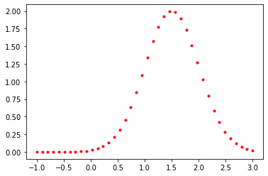

```python
from numpy import linspace
import matplotlib.pyplot as plt

# Funções com varios argumentos:
def fun(x,a,b):
    return a*exp(-a*(x-b)**2) # sino gaussiano

x=linspace(a,b,num=40) # modificar num e ver o que grafica
y=fun(x,2,1.5) # modificar segundo e terceiro argumento e ver o que grafica
plt.plot(x,y,'r.')
```

### Como graficar funções escalares de duas variável no Python?

- Seja $f:\mathbb{R}^2\rightarrow\mathbb{R}$ e dominio $\Omega=[a_x,b_x]\times[a_y,b_y]$.
- Para graficar $f$ em $\Omega$ no Python existem muitas formas.
- Aqui explicaremos como graficar pontos no espaço:
  - definir pontos $x\in\Omega$ (pode vir de um *dataset* ).
  - definir valores de $z$ calculando $z=f(x)$.
  - usar plot3D
- Recomendo executar o seguinte script no Spyder ou no PyCharm, para poder rotar a figura.

```
[<mpl_toolkits.mplot3d.art3d.Line3D at 0x22f1d7cc730>]
```

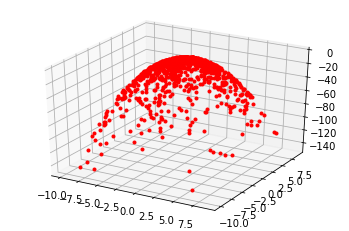

```python
from numpy import linspace,zeros
from numpy.random import rand, randint
import matplotlib.pyplot as plt
from mpl_toolkits import mplot3d

ax=-10
bx=10
ay=ax
by=bx

def f(x):
    return -x[:,0]**2-x[:,1]**2

# inventando pontos em Omega
numPontos=1000
vrand1=[rand() for i in range(numPontos)]
vrand2=[rand() for i in range(numPontos)]
X=zeros((numPontos,2))
X[:,0]=randint(ax,bx,numPontos)*vrand1
X[:,1]=randint(ay,by,numPontos)*vrand2

Z=f(X)

ax = plt.axes(projection='3d')
ax.plot3D(X[:,0],X[:,1],Z,'r.')
```

### Ajustando gráfico de funções aos dados

- O desafio agora é:
  - Conhecendo o *dataset* , como definir a função que melhor se ajuste ao dados do *dataset* ?
- Se conseguimos graficar o *dataset* , e reconhecemos que os pontos se "parecem" ao do gráfico de uma função "conhecida", podemos tentar modificar a função conhecida para que se ajuste aos dados.
  - Exemplo 1: se os pontos do dataset estão todos próximos de uma "reta", então vamos tentar definir a função: $$ f(x)=ax+b $$ onde $a$ e $b$ deverão ser ajustadas.
  - Exemplo 2: se os pontos do dataset estão todos próximos de uma "ondulação", então vamos tentar definir a função: $$ f(x)=a\ sin(bx+c) $$ onde $a$, $b$ e $c$ deverão ser ajustados.
  - Exemplo 3: se os pontos do dataset estão todos próximos de um "sino", então vamos tentar definir a função: $$ f(x)=a\ e^{-a\ (x-b)^2} $$ onde $a$, $b$ deverão ser ajustados.

### Exercício

- Escrever um código Python para
  - Carregar o '[dataset00](https://drive.google.com/file/d/1g_O1gOMhkRzIEsyJWbbyqyf3k7xdib3u/view?usp=sharing)'.
  - Graficar o *dataset*.
  - Encontre os valores de $a$ e $b$ para que o gráfico uma função afim $f(x)=ax+b$ se ajuste o melhor possível deste *dataset* .

# Fim da aula

- Redes Neurais Artificiais (RNA) e otimização
- Relação entre RNA e OGP
- Ajuste de funções aos dados
  - *Dataset* : como carregar e graficar
  - Vetores e funções: como definir e graficar
  - Ajustando gráfico de funções aos dados